# Technical Report - Deer Exclosures

Author

Maria Buist, Vuy Chao, Luke Monsma, Zachary Lindemulder, Priscilla Chen

Published

December 10, 2024

## Introduction

Our project was to analyze data from the Pierce Cedar Creek Institute to see the effects of deer on plant life in the area. The institute collected data over the last 10 years to evaluate how white-tailed deer overpopulation affects forest understory and ecosystem health by analyzing changes in vegetation cover inside and outside the exclosures. The data was collected from defined areas, either fenced to keep deer out or control areas where deer were free to graze. The measurements were taken by looking at 144 specific points in the area and recording which (if any) species were found there. From this method we can tell approximately how much coverage the species has in these areas by how many of the 144 points it was found at.

#### Research Question

How does deer presence affect plant diversity, controlling for possible effects of season and location?

#### Model Plan

Our model will have a response variable of **diversity** so we can see the impacts of the different variables on plant diversity. Since the response is a quantitative variable, we will be using a linear model for this data.

The primary predictor we are interested in is **fencing**, which will allow us to see if the presence or absence of deer have effects on the plant diversity. Fencing is a binary variable with the values “control” or “fenced”.

We will be including an interaction between **fencing** and **site** in our model, since the effects of fencing are different for each site where measurements were taken.

We will also include a random effect in our model, which will be a nested random effect of **season** within **site** within **year**. This is a random effect because they are categorical, we don’t have measurements from all possible values of them, and diversity can be very different between different combinations of those three variables.

Our dataset has 147 rows, allowing us to include 9 parameters according to the n/15 rule. The parameters we will estimate are:  
- Intercept (1) - Standard deviation of residuals (1)  
- Fencing (1) interacting with Site (3)  
- interaction terms (3)  
- a random effect of year, site, season nested together (3)

We will be predicting a total of 12 parameters, which is a bit beyond the n/15 rule of thumb. However, this model is the only one we found that worked well enough with the data to pass model assessment.

## Methods

#### Read Data

```r
exclosure_data = read_rds("exclosure_data.rds")
diversity_data = read_rds("diversity_data.rds")
```

#### Data Exploration

```r
virginiacreeper_fenced_df = subset(exclosure_data, common_name == 'Virginia creeper' & fencing == 'Fenced' & season == 'Spring' & site == 'West')
virginiacreeper_control_df = subset(exclosure_data, common_name == 'Virginia creeper' & fencing == 'Control' & season == 'Spring' & site == 'West')
```

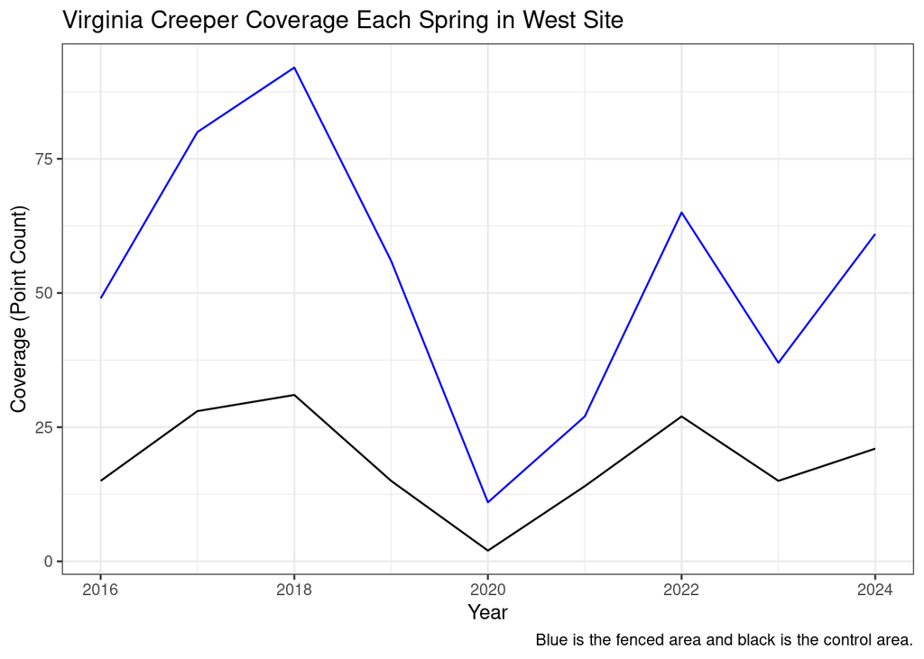

```r
gf_line(point_count ~ year, data=virginiacreeper_fenced_df, color = "blue") |>
  gf_line(point_count ~ year, data = virginiacreeper_control_df) |>
  gf_labs(title = "Virginia Creeper Coverage Each Spring in West Site",
          caption = "Blue is the fenced area and black is the control area.",
          x = "Year",
          y = "Coverage (Point Count)")
```

This plot compares the coverage of the Virginia Creeper in spring measurements in the West site between the fenced and control area. We are able to see that the fenced off areas have much more coverage of this species.

While we do not want to make graphs and analyze every single species in our data, this type of graph is useful for making those direct comparisons between the areas exposed to deer and fenced areas for some specific species with interesting trends.

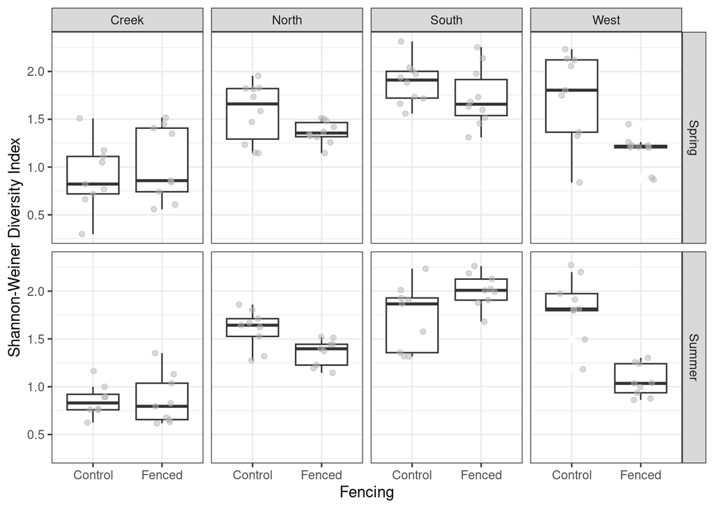

```r
gf_boxplot(sw_diversity ~ fencing, data = diversity_data, outlier.color = "white") |>
  gf_facet_grid(season ~ site) |>
  gf_jitter(width = 0.2, color = "gray70", alpha = 0.5) |>
  gf_labs(x = "Fencing",
          y = "Shannon-Weiner Diversity Index")
```

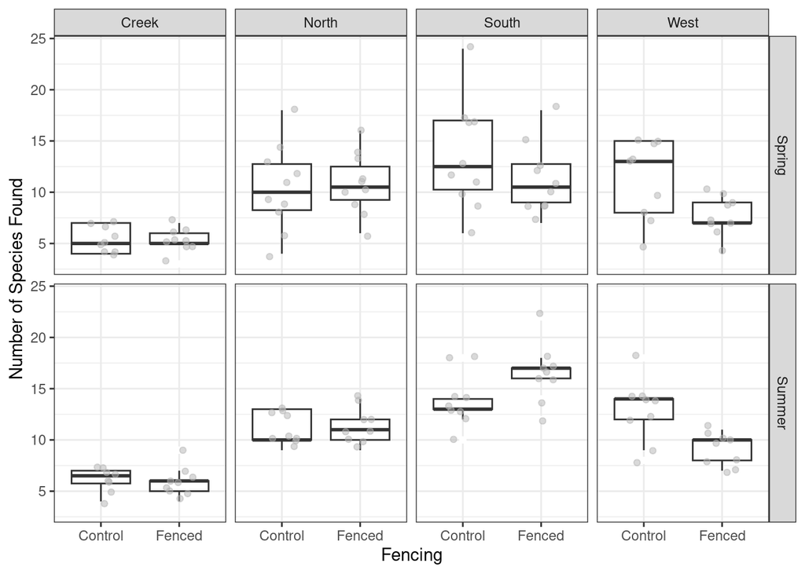

```r
gf_boxplot(richness ~ fencing, data = diversity_data, outlier.color = "white") |>
  gf_facet_grid(season ~ site) |>
  gf_jitter(width = 0.2, color = "gray70", alpha = 0.5) |>
  gf_labs(x = "Fencing",
          y = "Number of Species Found")
```

We have also created a couple of graphs showing the difference in plant diversity and richness between the fenced and control areas, with faceting by season and site to also compare between those variables. We can initially see that the effects of fencing are very different based on the site and season we are looking at.

#### Model Fitting

Here we fit a linear model to our data, as described in the model plan.

```r
model <- glmmTMB::glmmTMB(sw_diversity ~ fencing * site
                          + (1 | year / site / season),
                         data = diversity_data)
summary(model)
```

```
 Family: gaussian  ( identity )
Formula:          sw_diversity ~ fencing * site + (1 | year/site/season)
Data: diversity_data

     AIC      BIC   logLik deviance df.resid
    46.6     82.5    -11.3     22.6      135

Random effects:

Conditional model:
 Groups           Name        Variance  Std.Dev.
 season:site:year (Intercept) 5.838e-11 7.641e-06
 site:year        (Intercept) 1.675e-02 1.294e-01
 year             (Intercept) 4.750e-04 2.179e-02
 Residual                     5.563e-02 2.359e-01
Number of obs: 147, groups:  season:site:year, 74; site:year, 40; year, 10

Dispersion estimate for gaussian family (sigma^2): 0.0556

Conditional model:
                        Estimate Std. Error z value Pr(>|z|)
(Intercept)              0.88790    0.07120  12.471  < 2e-16 ***
fencingFenced            0.06433    0.07995   0.805   0.4210
siteNorth                0.70276    0.09822   7.155 8.38e-13 ***
siteSouth                0.92306    0.09822   9.398  < 2e-16 ***
siteWest                 0.88834    0.09922   8.953  < 2e-16 ***
fencingFenced:siteNorth -0.28783    0.11067  -2.601   0.0093 **
fencingFenced:siteSouth -0.01080    0.11067  -0.098   0.9222
fencingFenced:siteWest  -0.73051    0.11213  -6.515 7.27e-11 ***
---
Signif. codes:  0 '***' 0.001 '**' 0.01 '*' 0.05 '.' 0.1 ' ' 1
```

#### Model Assessment

```r
diversity_data <- diversity_data |>
 mutate(preds = predict(model),
 resids = resid(model))
```

Histogram of residuals checks for **normality of the residuals.**

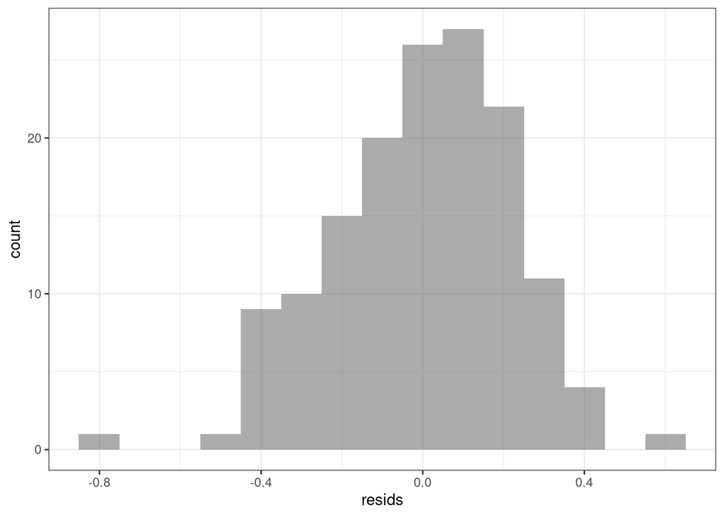

```r
gf_histogram(~ resids, data = diversity_data, bins = 15)
```

Model passes this condition since the distribution is roughly normal.

ACF checks the **independence of residuals.**

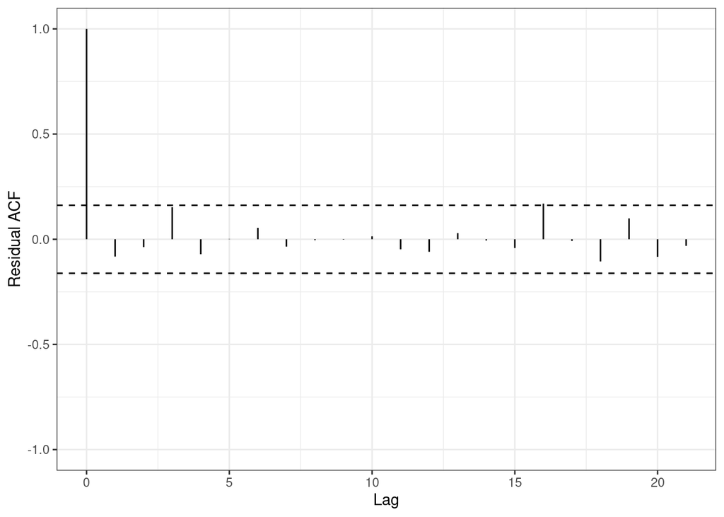

```r
s245::gf_acf(~ model)|>
  gf_lims(y=c(-1,1))
```

Model passes this condition since all the spikes are inside the boundaries.

Residual VS Fitted Plot checks **constant variance** and **lack of non-linearity.**

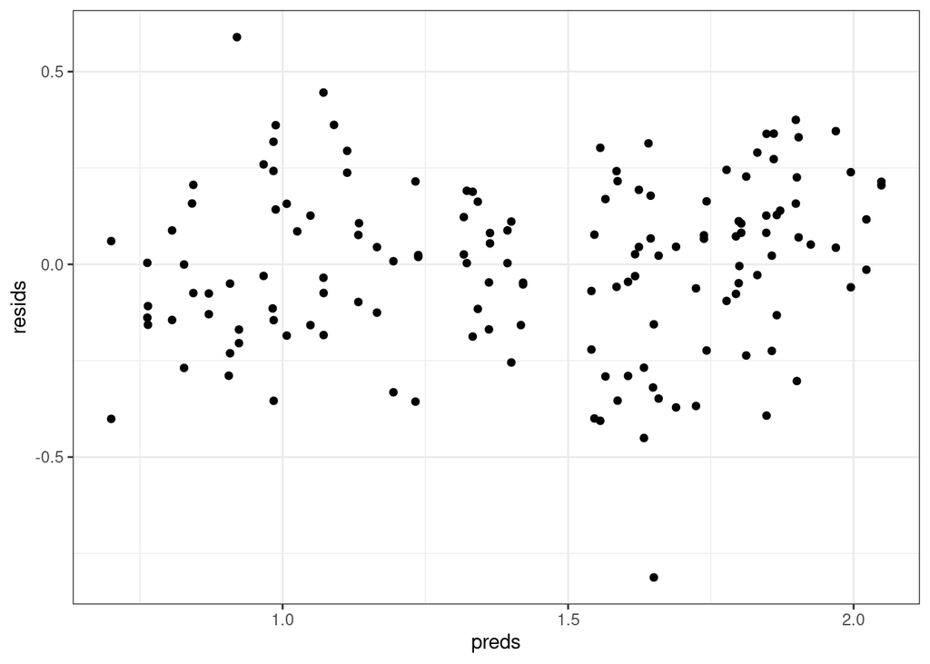

```r
gf_point(resids ~ preds, data = diversity_data)
```

The model passes lack of non-linearity because there is no visible trend. The model passes constant variance since the points are pretty evenly spread out.

## Inference and Conclusions

#### Prediction Plot

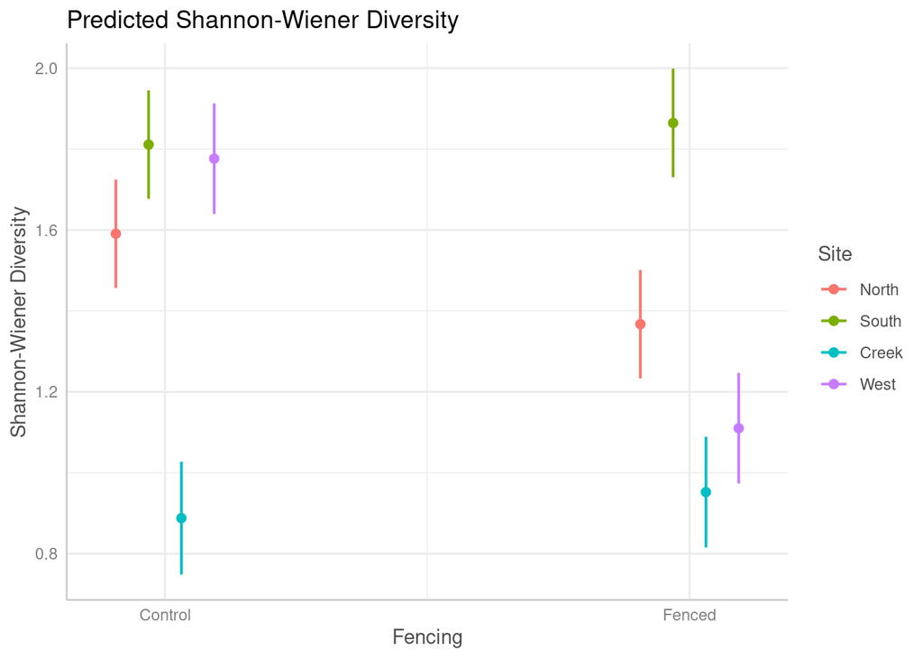

```r
ggpredict(model, terms = c("fencing", "site")) |>
  plot() |>
  gf_labs(title = "Predicted Shannon-Wiener Diversity",
          y = "Shannon-Wiener Diversity",
          x = "Fencing") |>
  gf_theme(scale_color_discrete("Site"))
```

This prediction plot provides a visualization of our linear regression model, with predicted diversity values displayed for each site and fencing condition.

#### Model Inference

We perform an anova test on our model to determine the strength of evidence it provides in answering our research question.

```r
car::Anova(model)
```

```
Analysis of Deviance Table (Type II Wald chisquare tests)

Response: sw_diversity
               Chisq Df Pr(>Chisq)
fencing       24.343  1  8.063e-07 ***
site         130.412  3  < 2.2e-16 ***
fencing:site  57.119  3  2.423e-12 ***
---
Signif. codes:  0 '***' 0.001 '**' 0.01 '*' 0.05 '.' 0.1 ' ' 1
```

#### Conclusion

Our model passes all assessment conditions, including independence and normality of residuals, constant variance, and lack of non-linearity.

There is very strong evidence (p < 0.0001) suggesting that fencing and site interacts and affect plant diversity. The direction of this effect is ambiguous. Based on prediction plot, we find that fencing is associated with decreased plant diversity for site West and North, and has little effects for site Creek and South.

Future investigation could control for the initial diversity present in each site, which could further isolate the effect of fencing. Other opportunities for future analysis would be using richness as the response variable instead of diversity, or some exploration of individual species of interest.